# BAN 614 Winter 2023 Final Project

## 1. Data preparation and Exploratory Data Analysis

- Follow concepts learnt in Week 2 to clean the data. If there are missing values then indicate how you plan to work with them.
- Explore the data set and use data visualization to describe underlying trends. You can make observations on the distributions of each variable.
- Report your detailed observations of any apparent relationship between customer status and each independent variable.
- Create any new columns if you need to at this point.
- Once you are done with the above, split the data set randomly into a training set (80%) and a test set (20%).

```
Rows: 6,999
Columns: 20
$ Gender           <fct> Female, Male, Male, Male, Female, Female, Male, Female, Female, Male, Male, Male, M…
$ SeniorCitizen    <int> 0, 0, 0, 0, 0, 0, 0, 0, 0, 0, 0, 0, 0, 0, 0, 0, 0, 0, 0, 0, 1, 0, 0, 0, 0, 0, 0, 0,…
$ Partner          <fct> Yes, No, No, No, No, No, No, No, Yes, No, Yes, No, Yes, No, No, Yes, No, No, Yes, N…
$ Dependents       <fct> No, No, No, No, No, No, Yes, No, No, Yes, Yes, No, No, No, No, Yes, No, Yes, Yes, N…
$ Tenure           <int> 1, 34, 2, 45, 2, 8, 22, 10, 28, 62, 13, 16, 58, 49, 25, 69, 52, 71, 10, 21, 1, 12, …
$ PhoneService     <fct> No, Yes, Yes, No, Yes, Yes, Yes, No, Yes, Yes, Yes, Yes, Yes, Yes, Yes, Yes, Yes, Y…
$ MultipleLines    <fct> No phone service, No, No, No phone service, No, Yes, Yes, No phone service, Yes, No…
$ InternetService  <fct> DSL, DSL, DSL, DSL, Fiber optic, Fiber optic, Fiber optic, DSL, Fiber optic, DSL, D…
$ OnlineSecurity   <fct> No, Yes, Yes, Yes, No, No, No, Yes, No, Yes, Yes, No internet service, No, No, Yes,…
$ OnlineBackup     <fct> Yes, No, Yes, No, No, No, Yes, No, No, Yes, No, No internet service, No, Yes, No, Y…
$ DeviceProtection <fct> No, Yes, No, Yes, No, Yes, No, No, Yes, No, No, No internet service, Yes, Yes, Yes,…
$ TechSupport      <fct> No, No, No, Yes, No, No, No, No, Yes, No, No, No internet service, No, No, Yes, Yes…
$ StreamingTV      <fct> No, No, No, No, No, Yes, Yes, No, Yes, No, No, No internet service, Yes, Yes, Yes, …
$ StreamingMovies  <fct> No, No, No, No, No, Yes, No, No, Yes, No, No, No internet service, Yes, Yes, Yes, Y…
$ Contract         <fct> Month-to-month, One year, Month-to-month, One year, Month-to-month, Month-to-month,…
$ PaperlessBilling <fct> Yes, No, Yes, No, Yes, Yes, Yes, No, Yes, No, Yes, No, No, Yes, Yes, No, No, No, No…
$ PaymentMethod    <fct> Electronic check, Mailed check, Mailed check, Bank transfer (automatic), Electronic…
$ MonthlyCharges   <dbl> 29.85, 56.95, 53.85, 42.30, 70.70, 99.65, 89.10, 29.75, 104.80, 56.15, 49.95, 18.95…
$ TotalCharges     <dbl> 29.85, 1889.50, 108.15, 1840.75, 151.65, 820.50, 1949.40, 301.90, 3046.05, 3487.95,…
$ Status           <chr> "Current", "Current", "Left", "Current", "Left", "Left", "Current", "Current", "Lef…
```

## Finding Missing Value Information

```
          Gender    SeniorCitizen          Partner       Dependents           Tenure     PhoneService
               0                0                0                0                0                0
   MultipleLines  InternetService   OnlineSecurity     OnlineBackup DeviceProtection      TechSupport
               0                0                0                0                0                0
     StreamingTV  StreamingMovies         Contract PaperlessBilling    PaymentMethod   MonthlyCharges
               0                0                0                0                0                0
    TotalCharges           Status
              11                0
```

```
          Gender    SeniorCitizen          Partner       Dependents           Tenure     PhoneService
               0                0                0                0                0                0
   MultipleLines  InternetService   OnlineSecurity     OnlineBackup DeviceProtection      TechSupport
               0                0                0                0                0                0
     StreamingTV  StreamingMovies         Contract PaperlessBilling    PaymentMethod   MonthlyCharges
               0                0                0                0                0                0
    TotalCharges           Status
               0                0
```

## Distribution of Variables

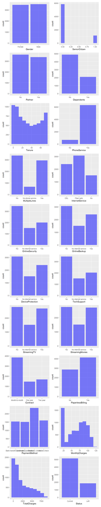

## Correlation Matrix

```
Correlation
Data        : Customer_Retention_complete_data
Method      : Pearson
Variables   :
Null hyp.   : variables x and y are not correlated
Alt. hyp.   : variables x and y are correlated
** Variables of type {factor} included without adjustment **

Correlation matrix:
                 Gender SeniorCitizen Partner Dependents Tenure PhoneService MultipleLines InternetService
SeniorCitizen    -0.00
Partner          -0.00   0.01
Dependents        0.01  -0.21          0.45
Tenure            0.01   0.02          0.38    0.16
PhoneService     -0.01   0.01          0.02   -0.00       0.01
MultipleLines    -0.01   0.15          0.14   -0.02       0.34  -0.02
InternetService  -0.00  -0.03          0.00    0.04      -0.03   0.39        -0.11
OnlineSecurity   -0.02  -0.13          0.15    0.15       0.33  -0.01         0.01         -0.03
OnlineBackup     -0.01  -0.01          0.15    0.09       0.37   0.02         0.12          0.04
DeviceProtection  0.00  -0.02          0.17    0.08       0.37   0.00         0.12          0.04
TechSupport      -0.01  -0.15          0.13    0.13       0.32  -0.02         0.01         -0.03
StreamingTV      -0.01   0.03          0.14    0.05       0.29   0.06         0.18          0.11
StreamingMovies  -0.01   0.05          0.13    0.02       0.30   0.04         0.18          0.10
Contract          0.00  -0.14          0.30    0.24       0.67   0.00         0.11          0.10
PaperlessBilling -0.01   0.16         -0.01   -0.11       0.01   0.02         0.16         -0.14
PaymentMethod     0.02  -0.04         -0.16   -0.04      -0.37  -0.00        -0.18          0.09
MonthlyCharges   -0.02   0.22          0.10   -0.11       0.25   0.25         0.43         -0.32
TotalCharges     -0.00   0.10          0.32    0.06       0.82   0.11         0.45         -0.18
Status           -0.01   0.15         -0.15   -0.16      -0.35   0.01         0.04         -0.05
                 OnlineSecurity OnlineBackup DeviceProtection TechSupport StreamingTV StreamingMovies
SeniorCitizen
Partner
Dependents
Tenure
PhoneService
MultipleLines
InternetService
OnlineSecurity
OnlineBackup      0.19
DeviceProtection  0.18           0.19
```

[output cut: 76 more lines]

```
PhoneService
MultipleLines
InternetService
OnlineSecurity
OnlineBackup
DeviceProtection
TechSupport
StreamingTV
StreamingMovies
Contract
PaperlessBilling 0.00
PaymentMethod    0.00     0.00
MonthlyCharges   0.00     0.00             0.00
TotalCharges     0.00     0.00             0.00          0.00
Status           0.00     0.00             0.00          0.00           0.00
```

### Correlation Matrix Observations

Customer Status does not have any apparent relationships with other variables. It has a very weak negative correlation with most of the variables except senior citizen, phone service, multiple lines and monthly charges. Customer status has very weak positive correlation with these variables. The variable with the strongest correlation with customer status is tenure. However, it only has -0.35 correlation with the status variable. This should not warrant any future attention.

```
# A tibble: 6,999 × 27
# Groups:   PhoneService, MultipleLines, InternetService, OnlineSecurity, OnlineBackup, DeviceProtection,
#   TechSupport, StreamingTV, StreamingMovies [322]
   Gender SeniorCitizen Partner Depen…¹ Tenure Phone…² Multi…³ Inter…⁴ Onlin…⁵ Onlin…⁶ Devic…⁷ TechS…⁸ Strea…⁹
   <fct>          <int> <fct>   <fct>    <int> <fct>   <fct>   <fct>   <fct>   <fct>   <fct>   <fct>   <fct>
 1 Female             0 Yes     No           1 No      No pho… DSL     No      Yes     No      No      No
 2 Male               0 No      No          34 Yes     No      DSL     Yes     No      Yes     No      No
 3 Male               0 No      No           2 Yes     No      DSL     Yes     Yes     No      No      No
 4 Male               0 No      No          45 No      No pho… DSL     Yes     No      Yes     Yes     No
 5 Female             0 No      No           2 Yes     No      Fiber … No      No      No      No      No
 6 Female             0 No      No           8 Yes     Yes     Fiber … No      No      Yes     No      Yes
 7 Male               0 No      Yes         22 Yes     Yes     Fiber … No      Yes     No      No      Yes
 8 Female             0 No      No          10 No      No pho… DSL     Yes     No      No      No      No
 9 Female             0 Yes     No          28 Yes     Yes     Fiber … No      No      Yes     Yes     Yes
10 Male               0 No      Yes         62 Yes     No      DSL     Yes     Yes     No      No      No
# … with 6,989 more rows, 14 more variables: StreamingMovies <fct>, Contract <fct>, PaperlessBilling <fct>,
#   PaymentMethod <fct>, MonthlyCharges <dbl>, TotalCharges <dbl>, Status <fct>, MultipleLines2 <chr>,
#   OnlineSecurity2 <chr>, OnlineBackup2 <chr>, DeviceProtection2 <chr>, TechSupport2 <chr>,
#   StreamingTV2 <chr>, StreamingMovies2 <chr>, and abbreviated variable names ¹Dependents, ²PhoneService,
#   ³MultipleLines, ⁴InternetService, ⁵OnlineSecurity, ⁶OnlineBackup, ⁷DeviceProtection, ⁸TechSupport,
#   ⁹StreamingTV
```

```
# A tibble: 5,599 × 27
# Groups:   PhoneService, MultipleLines, InternetService, OnlineSecurity, OnlineBackup, DeviceProtection,
#   TechSupport, StreamingTV, StreamingMovies [320]
   Gender SeniorCitizen Partner Depen…¹ Tenure Phone…² Multi…³ Inter…⁴ Onlin…⁵ Onlin…⁶ Devic…⁷ TechS…⁸ Strea…⁹
   <fct>          <int> <fct>   <fct>    <int> <fct>   <fct>   <fct>   <fct>   <fct>   <fct>   <fct>   <fct>
 1 Female             0 Yes     Yes         48 Yes     Yes     Fiber … No      No      No      No      No
 2 Male               0 No      Yes         35 Yes     No      Fiber … No      No      Yes     No      Yes
 3 Male               0 Yes     Yes         52 Yes     Yes     No      No int… No int… No int… No int… No int…
 4 Male               1 Yes     No           1 Yes     Yes     Fiber … No      No      No      No      No
 5 Male               0 No      Yes         17 Yes     No      DSL     No      Yes     Yes     Yes     Yes
 6 Male               0 Yes     Yes          4 Yes     Yes     No      No int… No int… No int… No int… No int…
 7 Male               0 No      No           1 No      No pho… DSL     No      No      No      No      No
 8 Female             0 No      No           7 Yes     No      Fiber … No      No      No      No      Yes
 9 Female             0 Yes     No          14 Yes     No      No      No int… No int… No int… No int… No int…
10 Male               0 No      No           1 Yes     No      DSL     No      No      No      No      No
# … with 5,589 more rows, 14 more variables: StreamingMovies <fct>, Contract <fct>, PaperlessBilling <fct>,
#   PaymentMethod <fct>, MonthlyCharges <dbl>, TotalCharges <dbl>, Status <fct>, MultipleLines2 <chr>,
#   OnlineSecurity2 <chr>, OnlineBackup2 <chr>, DeviceProtection2 <chr>, TechSupport2 <chr>,
#   StreamingTV2 <chr>, StreamingMovies2 <chr>, and abbreviated variable names ¹Dependents, ²PhoneService,
#   ³MultipleLines, ⁴InternetService, ⁵OnlineSecurity, ⁶OnlineBackup, ⁷DeviceProtection, ⁸TechSupport,
#   ⁹StreamingTV
```

## 2. Logistic Regression

- Use the training set to build a Logistic Regression model to predict the probability for losing a customer.
- Try different combinations of variables and arrive at the model that maximizes AUC (Area Under the Curve) for the ROC plots.
- For the model with the highest AUC, interpret each coefficient and provide guidance to the reader on how varying the different variables will influence customer behavior.
- Try different thresholds to identify the threshold with the highest prediction accuracy on the test set.

```
Call:  glm(formula = Status ~ Gender + SeniorCitizen + Partner + Dependents +
    Tenure + PhoneService + MultipleLines2 + InternetService +
    OnlineSecurity2 + OnlineBackup2 + DeviceProtection2 + TechSupport2 +
    StreamingTV2 + StreamingMovies2 + Contract + PaperlessBilling +
    PaymentMethod + MonthlyCharges + TotalCharges, family = binomial,
    data = customer.train)

Coefficients:
                         (Intercept)                            GenderMale
                            1.793887                             -0.030233
                       SeniorCitizen                            PartnerYes
                            0.168963                              0.045659
                       DependentsYes                                Tenure
                           -0.186073                             -0.056273
                     PhoneServiceYes                     MultipleLines2Yes
                            0.725852                              0.558526
          InternetServiceFiber optic                     InternetServiceNo
                            2.461164                             -2.537905
                  OnlineSecurity2Yes                      OnlineBackup2Yes
                           -0.092699                              0.147958
                DeviceProtection2Yes                       TechSupport2Yes
                            0.293994                             -0.148122
                     StreamingTV2Yes                   StreamingMovies2Yes
                            0.884805                              0.871848
                    ContractOne year                      ContractTwo year
                           -0.606423                             -1.342391
                 PaperlessBillingYes  PaymentMethodCredit card (automatic)
                            0.376249                             -0.088121
       PaymentMethodElectronic check             PaymentMethodMailed check
                            0.352417                             -0.006671
                      MonthlyCharges                          TotalCharges
                           -0.067972                              0.000281

Degrees of Freedom: 5598 Total (i.e. Null);  5575 Residual
Null Deviance:      6459
Residual Deviance: 4599     AIC: 4647
```

```
Call:
glm(formula = Status ~ Gender + SeniorCitizen + Partner + Dependents +
    Tenure + PhoneService + MultipleLines2 + InternetService +
    OnlineSecurity2 + OnlineBackup2 + DeviceProtection2 + TechSupport2 +
    StreamingTV2 + StreamingMovies2 + Contract + PaperlessBilling +
    PaymentMethod + MonthlyCharges + TotalCharges, family = binomial,
    data = customer.train)

Deviance Residuals:
    Min       1Q   Median       3Q      Max
-1.9073  -0.6728  -0.2807   0.7134   3.3844

Coefficients:
                                       Estimate Std. Error z value Pr(>|z|)
(Intercept)                           1.794e+00  9.194e-01   1.951 0.051042 .
GenderMale                           -3.023e-02  7.300e-02  -0.414 0.678773
SeniorCitizen                         1.690e-01  9.500e-02   1.779 0.075302 .
PartnerYes                            4.566e-02  8.828e-02   0.517 0.605017
DependentsYes                        -1.861e-01  1.015e-01  -1.834 0.066690 .
Tenure                               -5.627e-02  6.854e-03  -8.210  < 2e-16 ***
PhoneServiceYes                       7.259e-01  7.312e-01   0.993 0.320894
MultipleLines2Yes                     5.585e-01  2.000e-01   2.793 0.005222 **
InternetServiceFiber optic            2.461e+00  9.000e-01   2.735 0.006245 **
InternetServiceNo                    -2.538e+00  9.098e-01  -2.790 0.005276 **
OnlineSecurity2Yes                   -9.270e-02  2.005e-01  -0.462 0.643761
OnlineBackup2Yes                      1.480e-01  1.980e-01   0.747 0.454936
DeviceProtection2Yes                  2.940e-01  1.989e-01   1.478 0.139462
TechSupport2Yes                      -1.481e-01  2.037e-01  -0.727 0.467023
StreamingTV2Yes                       8.848e-01  3.677e-01   2.406 0.016121 *
StreamingMovies2Yes                   8.718e-01  3.690e-01   2.363 0.018134 *
ContractOne year                     -6.064e-01  1.217e-01  -4.982 6.31e-07 ***
ContractTwo year                     -1.342e+00  2.019e-01  -6.648 2.96e-11 ***
PaperlessBillingYes                   3.762e-01  8.404e-02   4.477 7.57e-06 ***
PaymentMethodCredit card (automatic) -8.812e-02  1.292e-01  -0.682 0.495301
PaymentMethodElectronic check         3.524e-01  1.066e-01   3.306 0.000945 ***
PaymentMethodMailed check            -6.671e-03  1.293e-01  -0.052 0.958838
MonthlyCharges                       -6.797e-02  3.582e-02  -1.898 0.057719 .
TotalCharges                          2.810e-04  7.802e-05   3.602 0.000316 ***
---
Signif. codes:  0 '***' 0.001 '**' 0.01 '*' 0.05 '.' 0.1 ' ' 1

(Dispersion parameter for binomial family taken to be 1)

    Null deviance: 6459.1  on 5598  degrees of freedom
Residual deviance: 4599.5  on 5575  degrees of freedom
AIC: 4647.5

Number of Fisher Scoring iterations: 6
```

```
         1          2          3          4          5          6
0.46038852 0.54655463 0.07019048 0.08889474 0.34731304 0.56204155
```

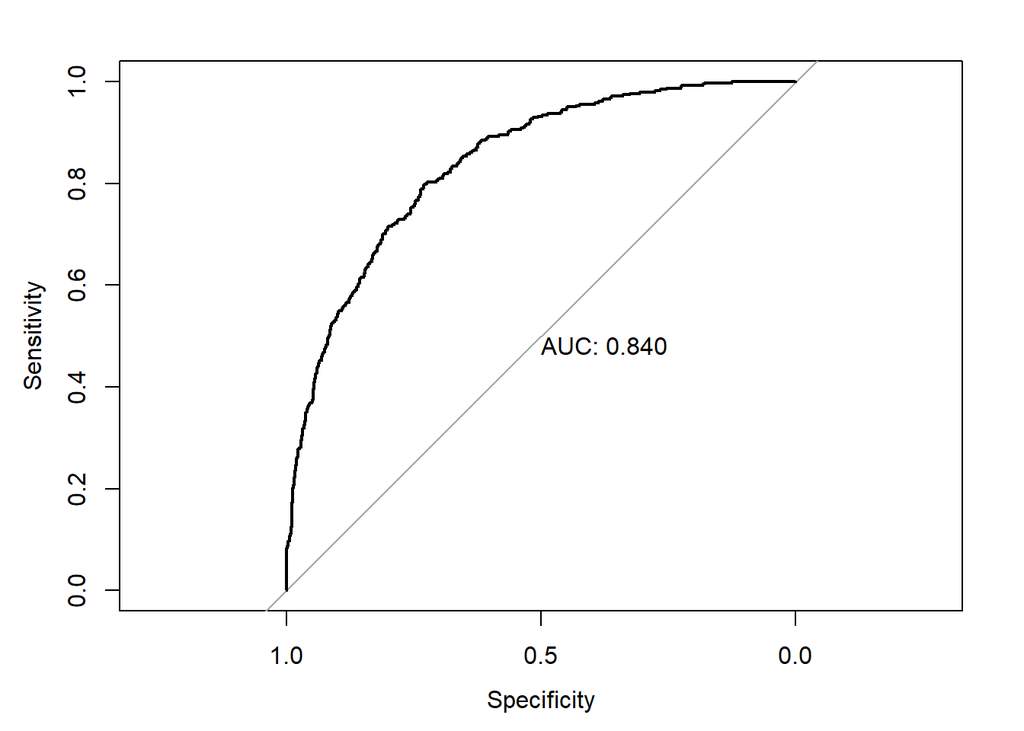

```
Call:
roc.default(response = customer.test$Status, predictor = customer_thresholds$Probability_Left,     plot = TRUE, print.auc = TRUE)

Data: customer_thresholds$Probability_Left in 1020 controls (customer.test$Status Current) < 380 cases (customer.test$Status Left).
Area under the curve: 0.8402
```

```
Call:  glm(formula = Status ~ Tenure + MultipleLines2 + InternetService +
    StreamingTV2 + StreamingMovies2 + Contract + PaperlessBilling +
    PaymentMethod + MonthlyCharges + TotalCharges, family = binomial,
    data = customer.train)

Coefficients:
                         (Intercept)                                Tenure
                           1.2509902                            -0.0565747
                   MultipleLines2Yes            InternetServiceFiber optic
                           0.4792611                             2.0216969
                   InternetServiceNo                       StreamingTV2Yes
                          -1.7828231                             0.6431040
                 StreamingMovies2Yes                      ContractOne year
                           0.6423085                            -0.6595510
                    ContractTwo year                   PaperlessBillingYes
                          -1.4896765                             0.3948027
PaymentMethodCredit card (automatic)         PaymentMethodElectronic check
                          -0.0928823                             0.3824917
           PaymentMethodMailed check                        MonthlyCharges
                          -0.0198672                            -0.0441700
                        TotalCharges
                           0.0002831

Degrees of Freedom: 5598 Total (i.e. Null);  5584 Residual
Null Deviance:      6459
Residual Deviance: 4629     AIC: 4659
```

```
Call:
glm(formula = Status ~ Tenure + MultipleLines2 + InternetService +
    StreamingTV2 + StreamingMovies2 + Contract + PaperlessBilling +
    PaymentMethod + MonthlyCharges + TotalCharges, family = binomial,
    data = customer.train)

Deviance Residuals:
    Min       1Q   Median       3Q      Max
-1.8670  -0.6765  -0.2852   0.7303   3.4425

Coefficients:
                                       Estimate Std. Error z value Pr(>|z|)
(Intercept)                           1.251e+00  2.988e-01   4.187 2.83e-05 ***
Tenure                               -5.657e-02  6.788e-03  -8.335  < 2e-16 ***
MultipleLines2Yes                     4.793e-01  9.489e-02   5.051 4.40e-07 ***
InternetServiceFiber optic            2.022e+00  1.884e-01  10.732  < 2e-16 ***
InternetServiceNo                    -1.783e+00  1.976e-01  -9.024  < 2e-16 ***
StreamingTV2Yes                       6.431e-01  1.054e-01   6.102 1.05e-09 ***
StreamingMovies2Yes                   6.423e-01  1.049e-01   6.125 9.06e-10 ***
ContractOne year                     -6.596e-01  1.202e-01  -5.487 4.09e-08 ***
ContractTwo year                     -1.490e+00  1.987e-01  -7.498 6.49e-14 ***
PaperlessBillingYes                   3.948e-01  8.352e-02   4.727 2.28e-06 ***
PaymentMethodCredit card (automatic) -9.288e-02  1.286e-01  -0.722 0.470030
PaymentMethodElectronic check         3.825e-01  1.059e-01   3.611 0.000305 ***
PaymentMethodMailed check            -1.987e-02  1.286e-01  -0.155 0.877186
MonthlyCharges                       -4.417e-02  5.804e-03  -7.611 2.73e-14 ***
TotalCharges                          2.831e-04  7.742e-05   3.656 0.000256 ***
---
Signif. codes:  0 '***' 0.001 '**' 0.01 '*' 0.05 '.' 0.1 ' ' 1

(Dispersion parameter for binomial family taken to be 1)

    Null deviance: 6459.1  on 5598  degrees of freedom
Residual deviance: 4628.6  on 5584  degrees of freedom
AIC: 4658.6

Number of Fisher Scoring iterations: 6
```

```
         1          2          3          4          5          6
0.46110806 0.58216138 0.10152824 0.08925463 0.34602244 0.57508315
```

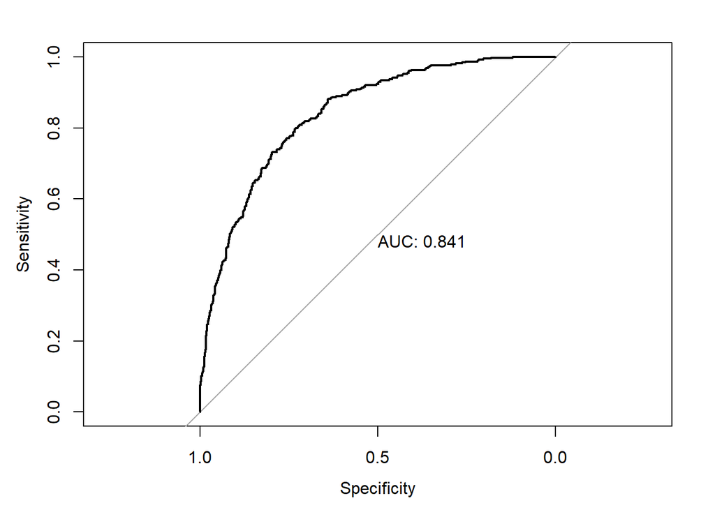

```
Call:
roc.default(response = customer.test$Status, predictor = customer_thresholds$Probability_Left,     plot = TRUE, print.auc = TRUE)

Data: customer_thresholds$Probability_Left in 1020 controls (customer.test$Status Current) < 380 cases (customer.test$Status Left).
Area under the curve: 0.8414
```

```
Call:  glm(formula = Status ~ Gender + InternetService + Tenure + TechSupport2 +
    StreamingTV2 + StreamingMovies2 + Contract + PaperlessBilling +
    PaymentMethod + MonthlyCharges + TotalCharges, family = binomial,
    data = customer.train)

Coefficients:
                         (Intercept)                            GenderMale
                           0.6138452                            -0.0196165
          InternetServiceFiber optic                     InternetServiceNo
                           1.5448325                            -1.4622063
                              Tenure                       TechSupport2Yes
                          -0.0554028                            -0.4004092
                     StreamingTV2Yes                   StreamingMovies2Yes
                           0.4889484                             0.4936103
                    ContractOne year                      ContractTwo year
                          -0.6875398                            -1.4566092
                 PaperlessBillingYes  PaymentMethodCredit card (automatic)
                           0.4187375                            -0.0792159
       PaymentMethodElectronic check             PaymentMethodMailed check
                           0.3875924                            -0.0254415
                      MonthlyCharges                          TotalCharges
                          -0.0266648                             0.0002963

Degrees of Freedom: 5598 Total (i.e. Null);  5583 Residual
Null Deviance:      6459
Residual Deviance: 4638     AIC: 4670
```

```
Call:
glm(formula = Status ~ Gender + InternetService + Tenure + TechSupport2 +
    StreamingTV2 + StreamingMovies2 + Contract + PaperlessBilling +
    PaymentMethod + MonthlyCharges + TotalCharges, family = binomial,
    data = customer.train)

Deviance Residuals:
    Min       1Q   Median       3Q      Max
-1.8607  -0.6836  -0.2840   0.7369   3.4094

Coefficients:
                                       Estimate Std. Error z value Pr(>|z|)
(Intercept)                           6.138e-01  2.908e-01   2.111 0.034760 *
GenderMale                           -1.962e-02  7.254e-02  -0.270 0.786841
InternetServiceFiber optic            1.545e+00  1.931e-01   8.000 1.24e-15 ***
InternetServiceNo                    -1.462e+00  1.913e-01  -7.645 2.08e-14 ***
Tenure                               -5.540e-02  6.773e-03  -8.179 2.85e-16 ***
TechSupport2Yes                      -4.004e-01  1.008e-01  -3.971 7.16e-05 ***
StreamingTV2Yes                       4.889e-01  1.036e-01   4.720 2.36e-06 ***
StreamingMovies2Yes                   4.936e-01  1.032e-01   4.783 1.73e-06 ***
ContractOne year                     -6.875e-01  1.200e-01  -5.729 1.01e-08 ***
ContractTwo year                     -1.457e+00  2.005e-01  -7.264 3.77e-13 ***
PaperlessBillingYes                   4.187e-01  8.343e-02   5.019 5.19e-07 ***
PaymentMethodCredit card (automatic) -7.922e-02  1.284e-01  -0.617 0.537303
PaymentMethodElectronic check         3.876e-01  1.057e-01   3.666 0.000246 ***
PaymentMethodMailed check            -2.544e-02  1.283e-01  -0.198 0.842847
MonthlyCharges                       -2.666e-02  5.597e-03  -4.764 1.90e-06 ***
TotalCharges                          2.963e-04  7.739e-05   3.829 0.000129 ***
---
Signif. codes:  0 '***' 0.001 '**' 0.01 '*' 0.05 '.' 0.1 ' ' 1

(Dispersion parameter for binomial family taken to be 1)

    Null deviance: 6459.1  on 5598  degrees of freedom
Residual deviance: 4638.3  on 5583  degrees of freedom
AIC: 4670.3

Number of Fisher Scoring iterations: 6
```

```
         1          2          3          4          5          6
0.46431546 0.61341243 0.06721365 0.09858952 0.40527284 0.61617233
```

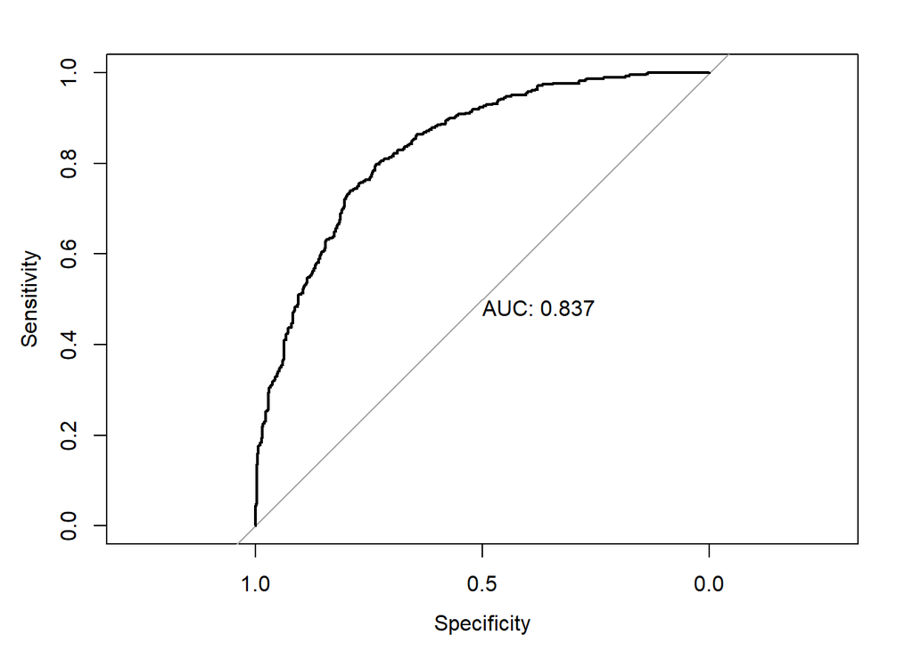

```
Call:
roc.default(response = customer.test$Status, predictor = customer_thresholds$Probability_Left,     plot = TRUE, print.auc = TRUE)

Data: customer_thresholds$Probability_Left in 1020 controls (customer.test$Status Current) < 380 cases (customer.test$Status Left).
Area under the curve: 0.837
```

```
Call:  glm(formula = Status ~ Gender + SeniorCitizen + Partner + Tenure +
    PhoneService + MultipleLines2 + InternetService + OnlineSecurity2 +
    OnlineBackup2 + DeviceProtection2 + TechSupport2 + StreamingTV2 +
    StreamingMovies2 + Contract + PaperlessBilling + PaymentMethod +
    MonthlyCharges + TotalCharges, family = binomial, data = customer.train)

Coefficients:
                         (Intercept)                            GenderMale
                           1.7913041                            -0.0296650
                       SeniorCitizen                            PartnerYes
                           0.2000346                            -0.0235900
                              Tenure                       PhoneServiceYes
                          -0.0564194                             0.7368900
                   MultipleLines2Yes            InternetServiceFiber optic
                           0.5633795                             2.4863536
                   InternetServiceNo                    OnlineSecurity2Yes
                          -2.5619303                            -0.0925228
                    OnlineBackup2Yes                  DeviceProtection2Yes
                           0.1476045                             0.2995831
                     TechSupport2Yes                       StreamingTV2Yes
                          -0.1451892                             0.8889955
                 StreamingMovies2Yes                      ContractOne year
                           0.8815576                            -0.6173967
                    ContractTwo year                   PaperlessBillingYes
                          -1.3628865                             0.3810591
PaymentMethodCredit card (automatic)         PaymentMethodElectronic check
                          -0.0902377                             0.3555790
           PaymentMethodMailed check                        MonthlyCharges
                          -0.0115713                            -0.0687647
                        TotalCharges
                           0.0002857

Degrees of Freedom: 5598 Total (i.e. Null);  5576 Residual
Null Deviance:      6459
Residual Deviance: 4603     AIC: 4649
```

```
Call:
glm(formula = Status ~ Gender + SeniorCitizen + Partner + Tenure +
    PhoneService + MultipleLines2 + InternetService + OnlineSecurity2 +
    OnlineBackup2 + DeviceProtection2 + TechSupport2 + StreamingTV2 +
    StreamingMovies2 + Contract + PaperlessBilling + PaymentMethod +
    MonthlyCharges + TotalCharges, family = binomial, data = customer.train)

Deviance Residuals:
    Min       1Q   Median       3Q      Max
-1.9152  -0.6722  -0.2818   0.7222   3.4018

Coefficients:
                                       Estimate Std. Error z value Pr(>|z|)
(Intercept)                           1.791e+00  9.194e-01   1.948  0.05137 .
GenderMale                           -2.967e-02  7.297e-02  -0.407  0.68433
SeniorCitizen                         2.000e-01  9.356e-02   2.138  0.03251 *
PartnerYes                           -2.359e-02  7.977e-02  -0.296  0.76745
Tenure                               -5.642e-02  6.856e-03  -8.230  < 2e-16 ***
PhoneServiceYes                       7.369e-01  7.312e-01   1.008  0.31357
MultipleLines2Yes                     5.634e-01  1.999e-01   2.818  0.00483 **
InternetServiceFiber optic            2.486e+00  8.999e-01   2.763  0.00573 **
InternetServiceNo                    -2.562e+00  9.097e-01  -2.816  0.00486 **
OnlineSecurity2Yes                   -9.252e-02  2.005e-01  -0.462  0.64439
OnlineBackup2Yes                      1.476e-01  1.980e-01   0.745  0.45601
DeviceProtection2Yes                  2.996e-01  1.989e-01   1.506  0.13208
TechSupport2Yes                      -1.452e-01  2.036e-01  -0.713  0.47586
StreamingTV2Yes                       8.890e-01  3.678e-01   2.417  0.01563 *
StreamingMovies2Yes                   8.816e-01  3.689e-01   2.390  0.01685 *
ContractOne year                     -6.174e-01  1.215e-01  -5.081 3.75e-07 ***
ContractTwo year                     -1.363e+00  2.015e-01  -6.762 1.36e-11 ***
PaperlessBillingYes                   3.811e-01  8.397e-02   4.538 5.67e-06 ***
PaymentMethodCredit card (automatic) -9.024e-02  1.292e-01  -0.698  0.48498
PaymentMethodElectronic check         3.556e-01  1.066e-01   3.336  0.00085 ***
PaymentMethodMailed check            -1.157e-02  1.292e-01  -0.090  0.92866
MonthlyCharges                       -6.876e-02  3.581e-02  -1.920  0.05485 .
TotalCharges                          2.857e-04  7.801e-05   3.662  0.00025 ***
---
Signif. codes:  0 '***' 0.001 '**' 0.01 '*' 0.05 '.' 0.1 ' ' 1

(Dispersion parameter for binomial family taken to be 1)

    Null deviance: 6459.1  on 5598  degrees of freedom
Residual deviance: 4602.9  on 5576  degrees of freedom
AIC: 4648.9

Number of Fisher Scoring iterations: 6
```

```
         1          2          3          4          5          6
0.43686160 0.57165103 0.07520598 0.08483651 0.34118728 0.55938386
```

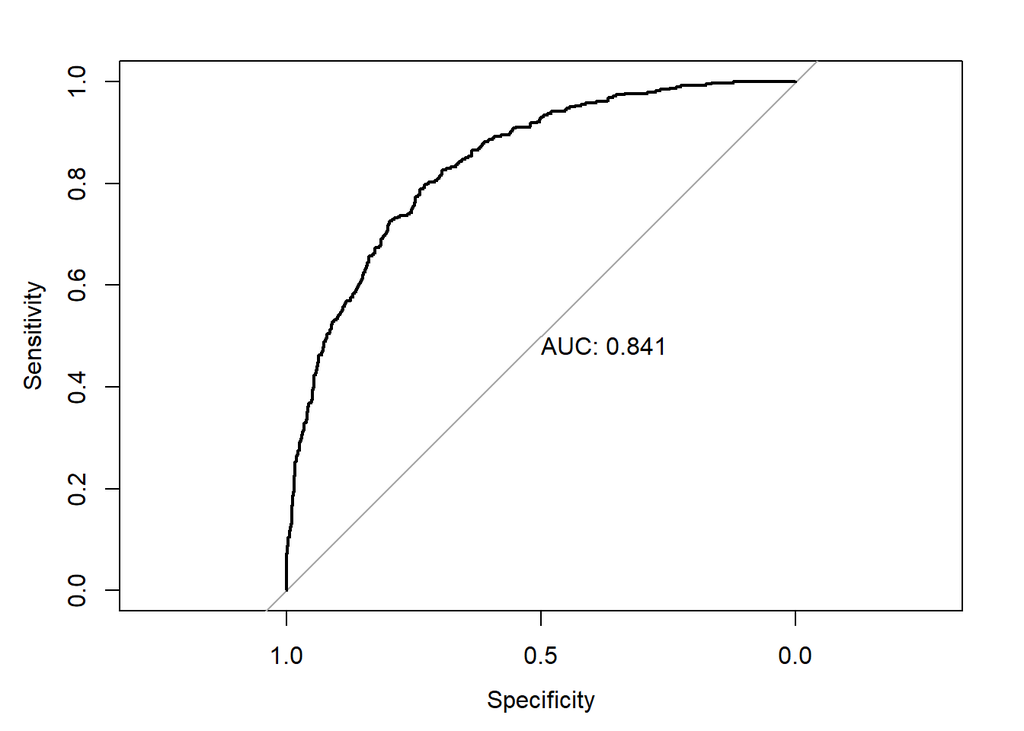

```
Call:
roc.default(response = customer.test$Status, predictor = customer_thresholds$Probability_Left,     plot = TRUE, print.auc = TRUE)

Data: customer_thresholds$Probability_Left in 1020 controls (customer.test$Status Current) < 380 cases (customer.test$Status Left).
Area under the curve: 0.8406
```

### Model Choice

```
Call:  glm(formula = Status ~ Tenure + MultipleLines2 + InternetService +
    StreamingTV2 + StreamingMovies2 + Contract + PaperlessBilling +
    PaymentMethod + MonthlyCharges + TotalCharges, family = binomial,
    data = customer.train)

Coefficients:
                         (Intercept)                                Tenure
                           1.2509902                            -0.0565747
                   MultipleLines2Yes            InternetServiceFiber optic
                           0.4792611                             2.0216969
                   InternetServiceNo                       StreamingTV2Yes
                          -1.7828231                             0.6431040
                 StreamingMovies2Yes                      ContractOne year
                           0.6423085                            -0.6595510
                    ContractTwo year                   PaperlessBillingYes
                          -1.4896765                             0.3948027
PaymentMethodCredit card (automatic)         PaymentMethodElectronic check
                          -0.0928823                             0.3824917
           PaymentMethodMailed check                        MonthlyCharges
                          -0.0198672                            -0.0441700
                        TotalCharges
                           0.0002831

Degrees of Freedom: 5598 Total (i.e. Null);  5584 Residual
Null Deviance:      6459
Residual Deviance: 4629     AIC: 4659
```

## Intepretation of Coefficients

### Tenure

```
   Tenure
0.9449959
```

### Multiple Lines

```
MultipleLines2Yes
         1.614881
```

The log odds change by a factor of 1.61 when the customer status does not have multiple lines to when the customer has multiple lines.

### Internet Service

```
InternetServiceFiber optic
                  7.551128
```

```
InternetServiceNo
        0.1681627
```

The log odds change by a factor of 7.55 when the customer status changes from DSL internet service to Fiber Optic. Additionally, The odds change by a factor of .17 when the customer has internet service and the customer does not have internet service.

### Streaming TV

```
StreamingTV2Yes
       1.902377
```

The log odds change by a factor of 1.9 when the customer does not have streaming TV to when the customer has streaming TV.

### Streaming Movies

```
StreamingMovies2Yes
           1.900864
```

The log odds change by a factor of 1.9 when the customer does not have streaming TV to when the customer has streaming movies

### Contract

```
ContractOne year
       0.5170835
```

```
ContractTwo year
       0.2254456
```

The log odds change by a factor of .52 when the customer has a month to month contract to when the customer has a one year contract. Additionally, The log odds change by a factor of .22 when the customer has a month to month contract to when the customer has a two year contract.

### Paperless Billing

```
PaperlessBillingYes
           1.484091
```

The log odds change by a factor of 1.48 when the customer does not have paperless billing to when the customer has Paperless Billing.

### Payment Method

```
PaymentMethodCredit card (automatic)
                           0.9113008
```

```
PaymentMethodElectronic check
                     1.465933
```

```
PaymentMethodMailed check
                0.9803289
```

The log odds change by a factor of .91 when the customer uses a credit card as a payment method rather than a bank transfer. The log odds change by a factor of 1.46 when the customer uses a electronic check as a payment method rather than a bank transfer. The log odds change by a factor of .98 when the customer uses a mailed check as a payment method rather than a bank transfer.

### Total Charges

```
TotalCharges
    1.000283
```

### Monthly Charges

```
MonthlyCharges
     0.9567913
```

### Prediction Probabilities with Selected Model

```
         1          2          3          4          5          6          7          8          9         10
0.46110806 0.58216138 0.10152824 0.08925463 0.34602244 0.57508315 0.23307063 0.07286211 0.30641827 0.08807231
```

```
        1         2         3         4         5         6         7         8         9        10
"Current"    "Left" "Current" "Current" "Current"    "Left" "Current" "Current" "Current" "Current"
```

```
Prediction_Classes Current Left
           Current     909  174
           Left        111  206
```

```
[1] 79.64286
```

```
        1         2         3         4         5         6         7         8         9        10
"Current"    "Left" "Current" "Current" "Current"    "Left" "Current" "Current" "Current" "Current"
```

```
Prediction_Classes Current Left
           Current     938  200
           Left         82  180
```

```
[1] 79.85714
```

```
        1         2         3         4         5         6         7         8         9        10
   "Left"    "Left" "Current" "Current" "Current"    "Left" "Current" "Current" "Current" "Current"
```

```
Prediction_Classes Current Left
           Current     892  163
           Left        128  217
```

```
[1] 79.21429
```

## 3. Naive Bayes

- Use the training set to build a Naive Bayes model to predict the probability for losing a customer.
- Try different combinations of variables and arrive at the model that maximizes AUC (Area Under the Curve) for the ROC plots.
- For the model with the highest AUC, try different thresholds to identify the threshold with the highest prediction accuracy on the test set.

```
# A tibble: 5,599 × 30
# Groups:   PhoneService, MultipleLines, InternetService, OnlineSecurity, OnlineBackup, DeviceProtection,
#   TechSupport, StreamingTV, StreamingMovies [320]
   Gender SeniorCitizen Partner Depen…¹ Tenure Phone…² Multi…³ Inter…⁴ Onlin…⁵ Onlin…⁶ Devic…⁷ TechS…⁸ Strea…⁹
   <fct>  <fct>         <fct>   <fct>    <int> <fct>   <fct>   <fct>   <fct>   <fct>   <fct>   <fct>   <fct>
 1 Female 0             Yes     Yes         48 Yes     Yes     Fiber … No      No      No      No      No
 2 Male   0             No      Yes         35 Yes     No      Fiber … No      No      Yes     No      Yes
 3 Male   0             Yes     Yes         52 Yes     Yes     No      No int… No int… No int… No int… No int…
 4 Male   1             Yes     No           1 Yes     Yes     Fiber … No      No      No      No      No
 5 Male   0             No      Yes         17 Yes     No      DSL     No      Yes     Yes     Yes     Yes
 6 Male   0             Yes     Yes          4 Yes     Yes     No      No int… No int… No int… No int… No int…
 7 Male   0             No      No           1 No      No pho… DSL     No      No      No      No      No
 8 Female 0             No      No           7 Yes     No      Fiber … No      No      No      No      Yes
 9 Female 0             Yes     No          14 Yes     No      No      No int… No int… No int… No int… No int…
10 Male   0             No      No           1 Yes     No      DSL     No      No      No      No      No
# … with 5,589 more rows, 17 more variables: StreamingMovies <fct>, Contract <fct>, PaperlessBilling <fct>,
#   PaymentMethod <fct>, MonthlyCharges <dbl>, TotalCharges <dbl>, Status <fct>, MultipleLines2 <chr>,
#   OnlineSecurity2 <chr>, OnlineBackup2 <chr>, DeviceProtection2 <chr>, TechSupport2 <chr>,
#   StreamingTV2 <chr>, StreamingMovies2 <chr>, Tenure_binned <fct>, mcharges_binned <fct>,
#   tcharges_binned <fct>, and abbreviated variable names ¹Dependents, ²PhoneService, ³MultipleLines,
#   ⁴InternetService, ⁵OnlineSecurity, ⁶OnlineBackup, ⁷DeviceProtection, ⁸TechSupport, ⁹StreamingTV
```

```
Naive Bayes Classifier for Discrete Predictors

Call:
naiveBayes.default(x = X, y = Y, laplace = laplace)

A-priori probabilities:
Y
  Current      Left
0.7363815 0.2636185

Conditional probabilities:
         Gender
Y            Female      Male
  Current 0.4921174 0.5078826
  Left    0.5060975 0.4939025

         SeniorCitizen
Y                 0         1
  Current 0.8724212 0.1275788
  Left    0.7479641 0.2520359

         Partner
Y                No       Yes
  Current 0.4719866 0.5280134
  Left    0.6443070 0.3556930

         Dependents
Y                No       Yes
  Current 0.6580152 0.3419848
  Left    0.8272313 0.1727687

         Tenure_binned
Y             Medium      Short       Long
  Current 0.43948504 0.30463276 0.25588220
  Left    0.29132877 0.66123995 0.04743129

         PhoneService
Y                 No        Yes
  Current 0.09386566 0.90613434
  Left    0.08875896 0.91124104
```

[output cut: 50 more lines]

```

         PaymentMethod
Y         Bank transfer (automatic) Credit card (automatic) Electronic check Mailed check
  Current                 0.2510308               0.2517584        0.2469076    0.2503032
  Left                    0.1355045               0.1205997        0.5779044    0.1659914

         mcharges_binned
Y             Small    Medium     Large
  Current 0.3718164 0.2842594 0.3439242
  Left    0.1951248 0.3157185 0.4891567

         tcharges_binned
Y             Medium      Small      Large
  Current 0.45549268 0.35289823 0.19160908
  Left    0.34688319 0.57181087 0.08130594
```

```
[1] Left    Left    Current Current Current Left
Levels: Current Left
```

```
        Current        Left
[1,] 0.37030830 0.629691700
[2,] 0.34299056 0.657009445
[3,] 0.99834633 0.001653669
[4,] 0.97008424 0.029915763
[5,] 0.66342223 0.336577774
[6,] 0.04834278 0.951657224
```

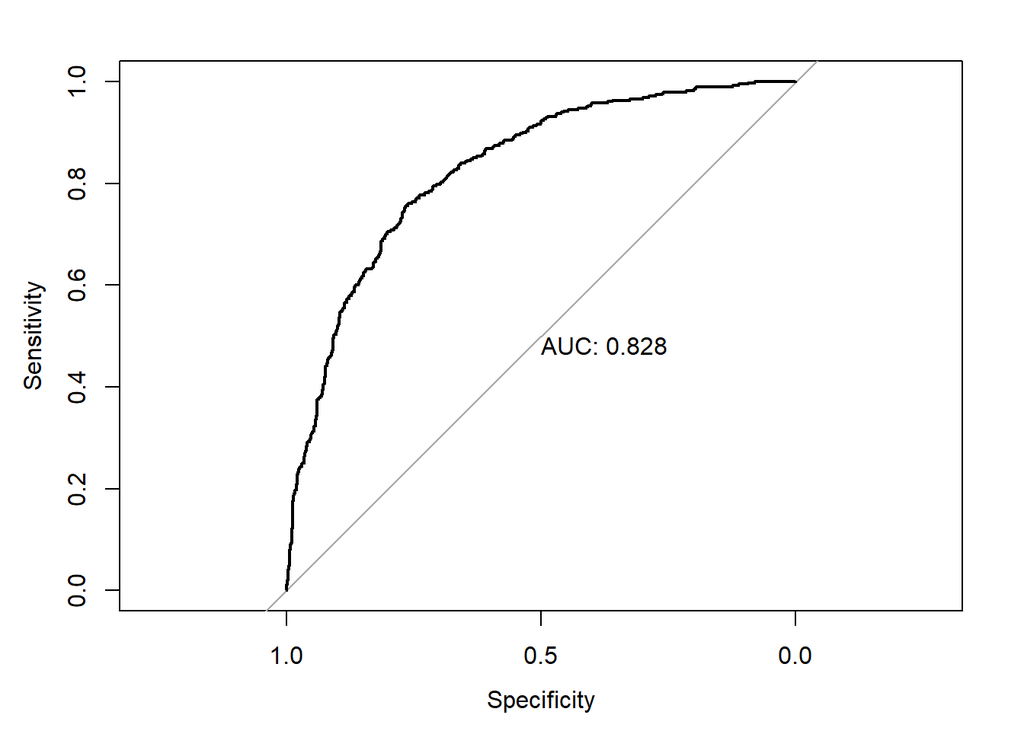

```
Call:
roc.default(response = customer.test$Status, predictor = customer_thresholds$Probability_Left,     plot = TRUE, print.auc = TRUE)

Data: customer_thresholds$Probability_Left in 1020 controls (customer.test$Status Current) > 380 cases (customer.test$Status Left).
Area under the curve: 0.8282
```

```
Naive Bayes Classifier for Discrete Predictors

Call:
naiveBayes.default(x = X, y = Y, laplace = laplace)

A-priori probabilities:
Y
  Current      Left
0.7363815 0.2636185

Conditional probabilities:
         Gender
Y            Female      Male
  Current 0.4921174 0.5078826
  Left    0.5060975 0.4939025

         SeniorCitizen
Y                 0         1
  Current 0.8724212 0.1275788
  Left    0.7479641 0.2520359

         Tenure_binned
Y             Medium      Short       Long
  Current 0.43948504 0.30463276 0.25588220
  Left    0.29132877 0.66123995 0.04743129

         PhoneService
Y                 No        Yes
  Current 0.09386566 0.90613434
  Left    0.08875896 0.91124104

         MultipleLines2
Y                No       Yes
  Current 0.5847708 0.4152341
  Left    0.5474322 0.4525813

         InternetService
Y                DSL Fiber optic         No
  Current 0.37690970  0.34901759 0.27407271
  Left    0.24593674  0.69443710 0.05962616
```

[output cut: 44 more lines]

```
  Left                    0.1355045               0.1205997        0.5779044
         PaymentMethod
Y         Mailed check
  Current    0.2503032
  Left       0.1659914

         mcharges_binned
Y             Small    Medium     Large
  Current 0.3718164 0.2842594 0.3439242
  Left    0.1951248 0.3157185 0.4891567

         tcharges_binned
Y             Medium      Small      Large
  Current 0.45549268 0.35289823 0.19160908
  Left    0.34688319 0.57181087 0.08130594
```

```
[1] Left    Left    Current Current Current Left
Levels: Current Left
```

```
        Current        Left
[1,] 0.33245732 0.667542684
[2,] 0.15086127 0.849138728
[3,] 0.99515638 0.004843621
[4,] 0.98234769 0.017652313
[5,] 0.77182826 0.228171739
[6,] 0.08018714 0.919812855
```

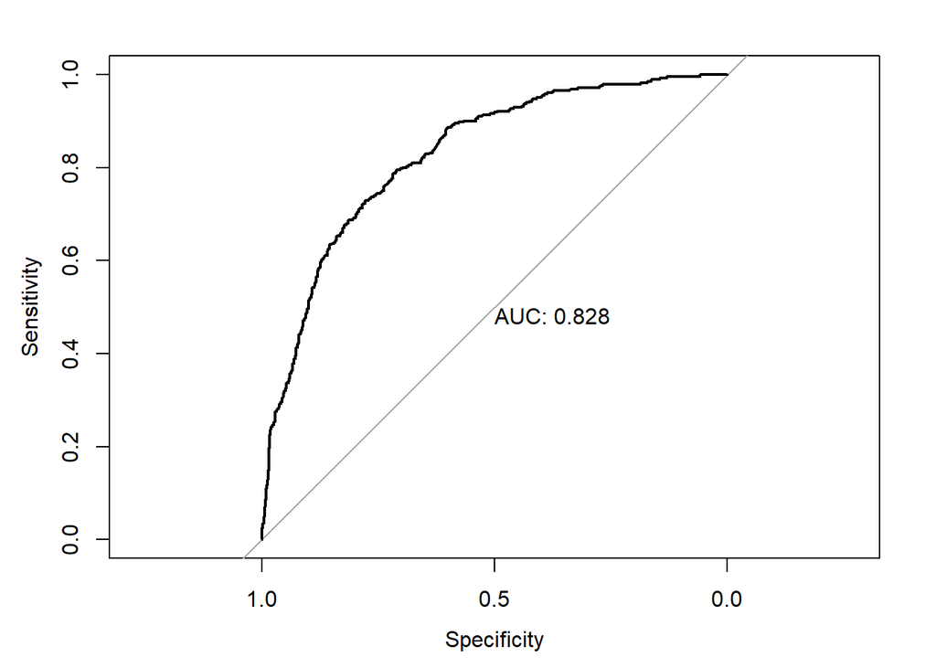

```
Call:
roc.default(response = customer.test$Status, predictor = customer_thresholds$Probability_Left,     plot = TRUE, print.auc = TRUE)

Data: customer_thresholds$Probability_Left in 1020 controls (customer.test$Status Current) > 380 cases (customer.test$Status Left).
Area under the curve: 0.8277
```

```
Naive Bayes Classifier for Discrete Predictors

Call:
naiveBayes.default(x = X, y = Y, laplace = laplace)

A-priori probabilities:
Y
  Current      Left
0.7363815 0.2636185

Conditional probabilities:
         SeniorCitizen
Y                 0         1
  Current 0.8724212 0.1275788
  Left    0.7479641 0.2520359

         Tenure_binned
Y             Medium      Short       Long
  Current 0.43948504 0.30463276 0.25588220
  Left    0.29132877 0.66123995 0.04743129

         PhoneService
Y                 No        Yes
  Current 0.09386566 0.90613434
  Left    0.08875896 0.91124104

         MultipleLines2
Y                No       Yes
  Current 0.5847708 0.4152341
  Left    0.5474322 0.4525813

         InternetService
Y                DSL Fiber optic         No
  Current 0.37690970  0.34901759 0.27407271
  Left    0.24593674  0.69443710 0.05962616

         OnlineSecurity2
Y                No       Yes
  Current 0.6640820 0.3359229
  Left    0.8455352 0.1544783
```

[output cut: 29 more lines]

```
  Left                    0.1355045               0.1205997        0.5779044
         PaymentMethod
Y         Mailed check
  Current    0.2503032
  Left       0.1659914

         mcharges_binned
Y             Small    Medium     Large
  Current 0.3718164 0.2842594 0.3439242
  Left    0.1951248 0.3157185 0.4891567

         tcharges_binned
Y             Medium      Small      Large
  Current 0.45549268 0.35289823 0.19160908
  Left    0.34688319 0.57181087 0.08130594
```

```
[1] Current Left    Current Current Current Left
Levels: Current Left
```

```
       Current       Left
[1,] 0.5829901 0.41700993
[2,] 0.3327641 0.66723592
[3,] 0.9753797 0.02462026
[4,] 0.8542346 0.14576545
[5,] 0.9094337 0.09056634
[6,] 0.1966042 0.80339582
```

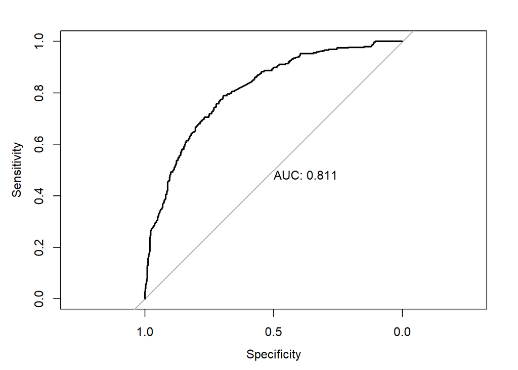

```
Call:
roc.default(response = customer.test$Status, predictor = customer_thresholds$Probability_Left,     plot = TRUE, print.auc = TRUE)

Data: customer_thresholds$Probability_Left in 1020 controls (customer.test$Status Current) > 380 cases (customer.test$Status Left).
Area under the curve: 0.8107
```

### Chosen Model

Out of the three different models, the best model is the second model without the variables dependents and partner. It has the same area under the curve as the first model, but it is a simpler model because it has fewer variables.

```
Naive Bayes Classifier for Discrete Predictors

Call:
naiveBayes.default(x = X, y = Y, laplace = laplace)

A-priori probabilities:
Y
  Current      Left
0.7363815 0.2636185

Conditional probabilities:
         Gender
Y            Female      Male
  Current 0.4921174 0.5078826
  Left    0.5060975 0.4939025

         SeniorCitizen
Y                 0         1
  Current 0.8724212 0.1275788
  Left    0.7479641 0.2520359

         Tenure_binned
Y             Medium      Short       Long
  Current 0.43948504 0.30463276 0.25588220
  Left    0.29132877 0.66123995 0.04743129

         PhoneService
Y                 No        Yes
  Current 0.09386566 0.90613434
  Left    0.08875896 0.91124104

         MultipleLines2
Y                No       Yes
  Current 0.5847708 0.4152341
  Left    0.5474322 0.4525813

         InternetService
Y                DSL Fiber optic         No
  Current 0.37690970  0.34901759 0.27407271
  Left    0.24593674  0.69443710 0.05962616
```

[output cut: 44 more lines]

```
  Left                    0.1355045               0.1205997        0.5779044
         PaymentMethod
Y         Mailed check
  Current    0.2503032
  Left       0.1659914

         mcharges_binned
Y             Small    Medium     Large
  Current 0.3718164 0.2842594 0.3439242
  Left    0.1951248 0.3157185 0.4891567

         tcharges_binned
Y             Medium      Small      Large
  Current 0.45549268 0.35289823 0.19160908
  Left    0.34688319 0.57181087 0.08130594
```

```
[1] Left    Left    Current Current Current Left
Levels: Current Left
```

```
customer.predictions Current Left
             Current     843  125
             Left        177  255
```

```
[1] 78.42857
```

```
Customer.predictions.test.class0.4 Current Left
                               No      803  111
                               Yes     217  269
```

```
[1] 76.57143
```

```
Customer.predictions.test.class0.6 Current Left
                               No      861  151
                               Yes     159  229
```

```
[1] 77.85714
```

## 4. Linear Discriminant Analysis

- Use the training set to build a model using Linear Discriminant Analysis to predict the probability for losing a customer.
- Try different combinations of variables and arrive at the model that maximizes AUC (Area Under the Curve) for the ROC plots.
- For the model with the highest AUC, try different thresholds to identify the threshold with the highest prediction accuracy on the test set.

```
Call:
lda(Status ~ Gender + SeniorCitizen + Partner + Dependents +
    Tenure + PhoneService + MultipleLines2 + InternetService +
    OnlineSecurity2 + OnlineBackup2 + DeviceProtection2 + TechSupport2 +
    StreamingTV2 + StreamingMovies2 + Contract + PaperlessBilling +
    PaymentMethod + MonthlyCharges + TotalCharges, data = customer.train)

Prior probabilities of groups:
  Current      Left
0.7363815 0.2636185

Group means:
        GenderMale SeniorCitizen1 PartnerYes DependentsYes   Tenure PhoneServiceYes
Current  0.5078826      0.1275770  0.5280136     0.3419840 37.55057       0.9061363
Left     0.4939024      0.2520325  0.3556911     0.1727642 17.80352       0.9112466
        MultipleLines2Yes InternetServiceFiber optic InternetServiceNo
Current         0.4152316                  0.3490177         0.2740723
Left            0.4525745                  0.6944444         0.0596206
        OnlineSecurity2Yes OnlineBackup2Yes DeviceProtection2Yes TechSupport2Yes
Current          0.3359204        0.3689061            0.3657531       0.3359204
Left             0.1544715        0.2757453            0.2906504       0.1558266
        StreamingTV2Yes StreamingMovies2Yes ContractOne year ContractTwo year
Current       0.3669658           0.3710890       0.25151589       0.31651710
Left          0.4376694           0.4363144       0.08807588       0.02439024
        PaperlessBillingYes PaymentMethodCredit card (automatic)
Current           0.5343197                            0.2517584
Left              0.7506775                            0.1205962
        PaymentMethodElectronic check PaymentMethodMailed check MonthlyCharges
Current                     0.2469076                 0.2503032       61.47105
Left                        0.5779133                 0.1659892       74.41087
        TotalCharges
Current     2560.563
Left        1511.754

Coefficients of linear discriminants:
                                               LD1
GenderMale                           -0.0243218497
SeniorCitizen1                        0.1865293209
PartnerYes                            0.0274051226
DependentsYes                        -0.1237137426
Tenure                               -0.0088400392
PhoneServiceYes                       0.3485803019
MultipleLines2Yes                     0.3608206099
InternetServiceFiber optic            1.5251524236
InternetServiceNo                    -1.4451650425
OnlineSecurity2Yes                   -0.1324485821
OnlineBackup2Yes                      0.0272393997
DeviceProtection2Yes                  0.1160343701
TechSupport2Yes                      -0.1874498128
StreamingTV2Yes                       0.5273920426
StreamingMovies2Yes                   0.5139283573
ContractOne year                     -0.4898871719
ContractTwo year                     -0.3041337581
PaperlessBillingYes                   0.2465617657
PaymentMethodCredit card (automatic) -0.0301644740
PaymentMethodElectronic check         0.3724382806
PaymentMethodMailed check            -0.0027579901
MonthlyCharges                       -0.0259157251
TotalCharges                         -0.0002296454
```

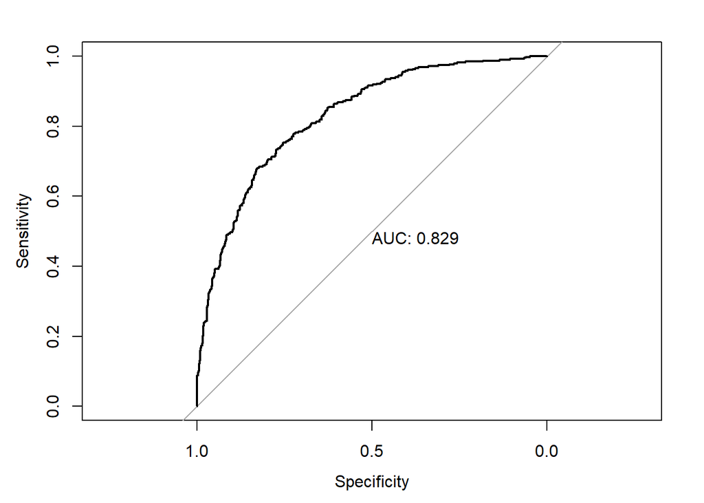

```
Call:
roc.default(response = customer_thresholds$Actual_Left, predictor = customer_thresholds$Probability_Left,     plot = TRUE, print.auc = TRUE)

Data: customer_thresholds$Probability_Left in 1020 controls (customer_thresholds$Actual_Left Current) < 380 cases (customer_thresholds$Actual_Left Left).
Area under the curve: 0.8289
```

```
Call:
lda(Status ~ Gender + Partner + SeniorCitizen + Dependents +
    Tenure + PhoneService + MultipleLines2 + InternetService +
    OnlineSecurity2 + OnlineBackup2 + DeviceProtection2 + TechSupport2 +
    StreamingTV2 + StreamingMovies2 + Contract + PaperlessBilling +
    PaymentMethod + MonthlyCharges + TotalCharges + StreamingMovies2 *
    StreamingTV2, data = customer.train)

Prior probabilities of groups:
  Current      Left
0.7363815 0.2636185

Group means:
        GenderMale PartnerYes SeniorCitizen1 DependentsYes   Tenure PhoneServiceYes
Current  0.5078826  0.5280136      0.1275770     0.3419840 37.55057       0.9061363
Left     0.4939024  0.3556911      0.2520325     0.1727642 17.80352       0.9112466
        MultipleLines2Yes InternetServiceFiber optic InternetServiceNo
Current         0.4152316                  0.3490177         0.2740723
Left            0.4525745                  0.6944444         0.0596206
        OnlineSecurity2Yes OnlineBackup2Yes DeviceProtection2Yes TechSupport2Yes
Current          0.3359204        0.3689061            0.3657531       0.3359204
Left             0.1544715        0.2757453            0.2906504       0.1558266
        StreamingTV2Yes StreamingMovies2Yes ContractOne year ContractTwo year
Current       0.3669658           0.3710890       0.25151589       0.31651710
Left          0.4376694           0.4363144       0.08807588       0.02439024
        PaperlessBillingYes PaymentMethodCredit card (automatic)
Current           0.5343197                            0.2517584
Left              0.7506775                            0.1205962
        PaymentMethodElectronic check PaymentMethodMailed check MonthlyCharges
Current                     0.2469076                 0.2503032       61.47105
Left                        0.5779133                 0.1659892       74.41087
        TotalCharges StreamingTV2Yes:StreamingMovies2Yes
Current     2560.563                           0.2672811
Left        1511.754                           0.3048780

Coefficients of linear discriminants:
                                               LD1
GenderMale                           -0.0241624326
PartnerYes                            0.0291418553
SeniorCitizen1                        0.1861418023
DependentsYes                        -0.1217956269
Tenure                               -0.0084319685
PhoneServiceYes                       0.3622242348
MultipleLines2Yes                     0.3656664493
InternetServiceFiber optic            1.5406148233
InternetServiceNo                    -1.4861957096
OnlineSecurity2Yes                   -0.1249203040
OnlineBackup2Yes                      0.0339987340
DeviceProtection2Yes                  0.1181750128
TechSupport2Yes                      -0.1843229423
StreamingTV2Yes                       0.4249292319
StreamingMovies2Yes                   0.4135895610
ContractOne year                     -0.4905409916
ContractTwo year                     -0.3116292169
PaperlessBillingYes                   0.2481474198
PaymentMethodCredit card (automatic) -0.0277819325
PaymentMethodElectronic check         0.3711189742
PaymentMethodMailed check            -0.0048955391
MonthlyCharges                       -0.0263413473
TotalCharges                         -0.0002366655
StreamingTV2Yes:StreamingMovies2Yes   0.2200558228
```

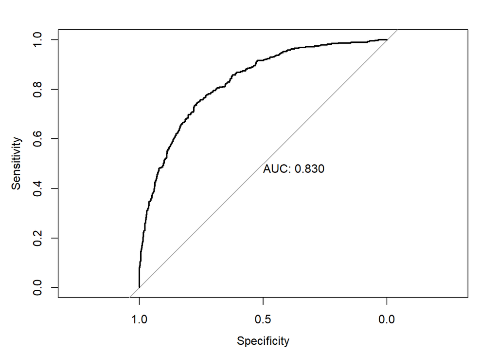

```
Call:
roc.default(response = customer_thresholds$Actual_Left, predictor = customer_thresholds$Probability_Left,     plot = TRUE, print.auc = TRUE)

Data: customer_thresholds$Probability_Left in 1020 controls (customer_thresholds$Actual_Left Current) < 380 cases (customer_thresholds$Actual_Left Left).
Area under the curve: 0.8298
```

```
Call:
lda(Status ~ Gender + Partner + SeniorCitizen + Dependents +
    Tenure^2 + PhoneService + MultipleLines2 + InternetService +
    OnlineSecurity2 + OnlineBackup2 + DeviceProtection2 + TechSupport2 +
    StreamingTV2 + StreamingMovies2 + Contract + PaperlessBilling +
    PaymentMethod + MonthlyCharges + TotalCharges + StreamingMovies2 *
    StreamingTV2, data = customer.train)

Prior probabilities of groups:
  Current      Left
0.7363815 0.2636185

Group means:
        GenderMale PartnerYes SeniorCitizen1 DependentsYes   Tenure PhoneServiceYes
Current  0.5078826  0.5280136      0.1275770     0.3419840 37.55057       0.9061363
Left     0.4939024  0.3556911      0.2520325     0.1727642 17.80352       0.9112466
        MultipleLines2Yes InternetServiceFiber optic InternetServiceNo
Current         0.4152316                  0.3490177         0.2740723
Left            0.4525745                  0.6944444         0.0596206
        OnlineSecurity2Yes OnlineBackup2Yes DeviceProtection2Yes TechSupport2Yes
Current          0.3359204        0.3689061            0.3657531       0.3359204
Left             0.1544715        0.2757453            0.2906504       0.1558266
        StreamingTV2Yes StreamingMovies2Yes ContractOne year ContractTwo year
Current       0.3669658           0.3710890       0.25151589       0.31651710
Left          0.4376694           0.4363144       0.08807588       0.02439024
        PaperlessBillingYes PaymentMethodCredit card (automatic)
Current           0.5343197                            0.2517584
Left              0.7506775                            0.1205962
        PaymentMethodElectronic check PaymentMethodMailed check MonthlyCharges
Current                     0.2469076                 0.2503032       61.47105
Left                        0.5779133                 0.1659892       74.41087
        TotalCharges StreamingTV2Yes:StreamingMovies2Yes
Current     2560.563                           0.2672811
Left        1511.754                           0.3048780

Coefficients of linear discriminants:
                                               LD1
GenderMale                           -0.0241624326
PartnerYes                            0.0291418553
SeniorCitizen1                        0.1861418023
DependentsYes                        -0.1217956269
Tenure                               -0.0084319685
PhoneServiceYes                       0.3622242348
MultipleLines2Yes                     0.3656664493
InternetServiceFiber optic            1.5406148233
InternetServiceNo                    -1.4861957096
OnlineSecurity2Yes                   -0.1249203040
OnlineBackup2Yes                      0.0339987340
DeviceProtection2Yes                  0.1181750128
TechSupport2Yes                      -0.1843229423
StreamingTV2Yes                       0.4249292319
StreamingMovies2Yes                   0.4135895610
ContractOne year                     -0.4905409916
ContractTwo year                     -0.3116292169
PaperlessBillingYes                   0.2481474198
PaymentMethodCredit card (automatic) -0.0277819325
PaymentMethodElectronic check         0.3711189742
PaymentMethodMailed check            -0.0048955391
MonthlyCharges                       -0.0263413473
TotalCharges                         -0.0002366655
StreamingTV2Yes:StreamingMovies2Yes   0.2200558228
```

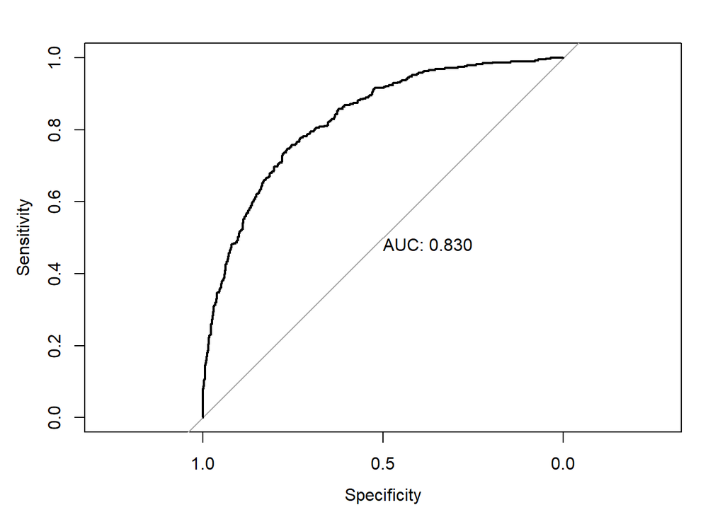

```
Call:
roc.default(response = customer_thresholds$Actual_Left, predictor = customer_thresholds$Probability_Left,     plot = TRUE, print.auc = TRUE)

Data: customer_thresholds$Probability_Left in 1020 controls (customer_thresholds$Actual_Left Current) < 380 cases (customer_thresholds$Actual_Left Left).
Area under the curve: 0.8298
```

### Chosen Model

```
Call:
lda(Status ~ Gender + SeniorCitizen + Partner + Dependents +
    Tenure + PhoneService + MultipleLines2 + InternetService +
    OnlineSecurity2 + OnlineBackup2 + DeviceProtection2 + TechSupport2 +
    StreamingTV2 + StreamingMovies2 + Contract + PaperlessBilling +
    PaymentMethod + MonthlyCharges + TotalCharges, data = customer.train)

Prior probabilities of groups:
  Current      Left
0.7363815 0.2636185

Group means:
        GenderMale SeniorCitizen1 PartnerYes DependentsYes   Tenure PhoneServiceYes
Current  0.5078826      0.1275770  0.5280136     0.3419840 37.55057       0.9061363
Left     0.4939024      0.2520325  0.3556911     0.1727642 17.80352       0.9112466
        MultipleLines2Yes InternetServiceFiber optic InternetServiceNo
Current         0.4152316                  0.3490177         0.2740723
Left            0.4525745                  0.6944444         0.0596206
        OnlineSecurity2Yes OnlineBackup2Yes DeviceProtection2Yes TechSupport2Yes
Current          0.3359204        0.3689061            0.3657531       0.3359204
Left             0.1544715        0.2757453            0.2906504       0.1558266
        StreamingTV2Yes StreamingMovies2Yes ContractOne year ContractTwo year
Current       0.3669658           0.3710890       0.25151589       0.31651710
Left          0.4376694           0.4363144       0.08807588       0.02439024
        PaperlessBillingYes PaymentMethodCredit card (automatic)
Current           0.5343197                            0.2517584
Left              0.7506775                            0.1205962
        PaymentMethodElectronic check PaymentMethodMailed check MonthlyCharges
Current                     0.2469076                 0.2503032       61.47105
Left                        0.5779133                 0.1659892       74.41087
        TotalCharges
Current     2560.563
Left        1511.754

Coefficients of linear discriminants:
                                               LD1
GenderMale                           -0.0243218497
SeniorCitizen1                        0.1865293209
PartnerYes                            0.0274051226
DependentsYes                        -0.1237137426
Tenure                               -0.0088400392
PhoneServiceYes                       0.3485803019
MultipleLines2Yes                     0.3608206099
InternetServiceFiber optic            1.5251524236
InternetServiceNo                    -1.4451650425
OnlineSecurity2Yes                   -0.1324485821
OnlineBackup2Yes                      0.0272393997
DeviceProtection2Yes                  0.1160343701
TechSupport2Yes                      -0.1874498128
StreamingTV2Yes                       0.5273920426
StreamingMovies2Yes                   0.5139283573
ContractOne year                     -0.4898871719
ContractTwo year                     -0.3041337581
PaperlessBillingYes                   0.2465617657
PaymentMethodCredit card (automatic) -0.0301644740
PaymentMethodElectronic check         0.3724382806
PaymentMethodMailed check            -0.0027579901
MonthlyCharges                       -0.0259157251
TotalCharges                         -0.0002296454
```

```
Confusion Matrix and Statistics

          Reference
Prediction Current Left
   Current     907  179
   Left        113  201

               Accuracy : 0.7914
                 95% CI : (0.7692, 0.8124)
    No Information Rate : 0.7286
    P-Value [Acc > NIR] : 3.354e-08

                  Kappa : 0.4423

 Mcnemar's Test P-Value : 0.0001425

            Sensitivity : 0.8892
            Specificity : 0.5289
         Pos Pred Value : 0.8352
         Neg Pred Value : 0.6401
             Prevalence : 0.7286
         Detection Rate : 0.6479
   Detection Prevalence : 0.7757
      Balanced Accuracy : 0.7091

       'Positive' Class : Current
```

```
Confusion Matrix and Statistics

          Reference
Prediction Current Left
   Current     867  144
   Left        153  236

               Accuracy : 0.7879
                 95% CI : (0.7655, 0.809)
    No Information Rate : 0.7286
    P-Value [Acc > NIR] : 1.875e-07

                  Kappa : 0.4676

 Mcnemar's Test P-Value : 0.6425

            Sensitivity : 0.8500
            Specificity : 0.6211
         Pos Pred Value : 0.8576
         Neg Pred Value : 0.6067
             Prevalence : 0.7286
         Detection Rate : 0.6193
   Detection Prevalence : 0.7221
      Balanced Accuracy : 0.7355

       'Positive' Class : Current
```

```
Confusion Matrix and Statistics

          Reference
Prediction Current Left
   Current     948  212
   Left         72  168

               Accuracy : 0.7971
                 95% CI : (0.7751, 0.8179)
    No Information Rate : 0.7286
    P-Value [Acc > NIR] : 1.714e-09

                  Kappa : 0.4201

 Mcnemar's Test P-Value : < 2.2e-16

            Sensitivity : 0.9294
            Specificity : 0.4421
         Pos Pred Value : 0.8172
         Neg Pred Value : 0.7000
             Prevalence : 0.7286
         Detection Rate : 0.6771
   Detection Prevalence : 0.8286
      Balanced Accuracy : 0.6858

       'Positive' Class : Current
```

## 5. Quadratic Discriminant Analysis

- Use the training set to build a model using Quadratic Discriminant Analysis to predict the probability for losing a customer.
- Try different combinations of variables and arrive at the model that maximizes AUC (Area Under the Curve) for the ROC plots.
- For the model with the highest AUC, try different thresholds to identify the threshold with the highest prediction accuracy on the test set.

```
Call:
qda(Status ~ Gender + Partner + SeniorCitizen + Dependents +
    Tenure + PhoneService + MultipleLines2 + InternetService +
    OnlineSecurity2 + OnlineBackup2 + DeviceProtection2 + TechSupport2 +
    StreamingTV2 + StreamingMovies2 + Contract + PaperlessBilling +
    PaymentMethod + MonthlyCharges + TotalCharges, data = customer.train)

Prior probabilities of groups:
  Current      Left
0.7363815 0.2636185

Group means:
        GenderMale PartnerYes SeniorCitizen1 DependentsYes   Tenure PhoneServiceYes
Current  0.5078826  0.5280136      0.1275770     0.3419840 37.55057       0.9061363
Left     0.4939024  0.3556911      0.2520325     0.1727642 17.80352       0.9112466
        MultipleLines2Yes InternetServiceFiber optic InternetServiceNo
Current         0.4152316                  0.3490177         0.2740723
Left            0.4525745                  0.6944444         0.0596206
        OnlineSecurity2Yes OnlineBackup2Yes DeviceProtection2Yes TechSupport2Yes
Current          0.3359204        0.3689061            0.3657531       0.3359204
Left             0.1544715        0.2757453            0.2906504       0.1558266
        StreamingTV2Yes StreamingMovies2Yes ContractOne year ContractTwo year
Current       0.3669658           0.3710890       0.25151589       0.31651710
Left          0.4376694           0.4363144       0.08807588       0.02439024
        PaperlessBillingYes PaymentMethodCredit card (automatic)
Current           0.5343197                            0.2517584
Left              0.7506775                            0.1205962
        PaymentMethodElectronic check PaymentMethodMailed check MonthlyCharges
Current                     0.2469076                 0.2503032       61.47105
Left                        0.5779133                 0.1659892       74.41087
        TotalCharges
Current     2560.563
Left        1511.754
```

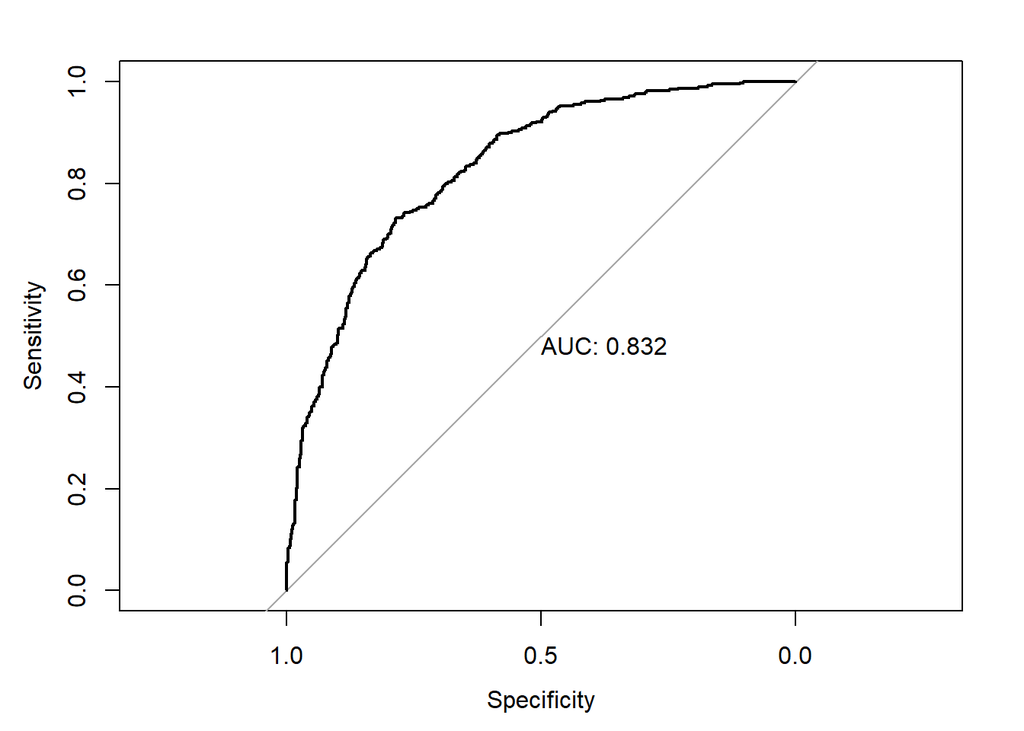

```
Call:
roc.default(response = customer_thresholds$Actual_Left, predictor = customer_thresholds$Probability_Left,     plot = TRUE, print.auc = TRUE)

Data: customer_thresholds$Probability_Left in 1020 controls (customer_thresholds$Actual_Left Current) < 380 cases (customer_thresholds$Actual_Left Left).
Area under the curve: 0.8316
```

```
Call:
qda(Status ~ Gender + Partner + SeniorCitizen + Dependents +
    Tenure + PhoneService + MultipleLines2 + InternetService +
    OnlineSecurity2 + OnlineBackup2 + DeviceProtection2 + TechSupport2 +
    StreamingTV2 + StreamingMovies2 + Contract + PaperlessBilling +
    PaymentMethod + log(MonthlyCharges) + TotalCharges, data = customer.train)

Prior probabilities of groups:
  Current      Left
0.7363815 0.2636185

Group means:
        GenderMale PartnerYes SeniorCitizen1 DependentsYes   Tenure PhoneServiceYes
Current  0.5078826  0.5280136      0.1275770     0.3419840 37.55057       0.9061363
Left     0.4939024  0.3556911      0.2520325     0.1727642 17.80352       0.9112466
        MultipleLines2Yes InternetServiceFiber optic InternetServiceNo
Current         0.4152316                  0.3490177         0.2740723
Left            0.4525745                  0.6944444         0.0596206
        OnlineSecurity2Yes OnlineBackup2Yes DeviceProtection2Yes TechSupport2Yes
Current          0.3359204        0.3689061            0.3657531       0.3359204
Left             0.1544715        0.2757453            0.2906504       0.1558266
        StreamingTV2Yes StreamingMovies2Yes ContractOne year ContractTwo year
Current       0.3669658           0.3710890       0.25151589       0.31651710
Left          0.4376694           0.4363144       0.08807588       0.02439024
        PaperlessBillingYes PaymentMethodCredit card (automatic)
Current           0.5343197                            0.2517584
Left              0.7506775                            0.1205962
        PaymentMethodElectronic check PaymentMethodMailed check log(MonthlyCharges)
Current                     0.2469076                 0.2503032            3.950114
Left                        0.5779133                 0.1659892            4.229745
        TotalCharges
Current     2560.563
Left        1511.754
```

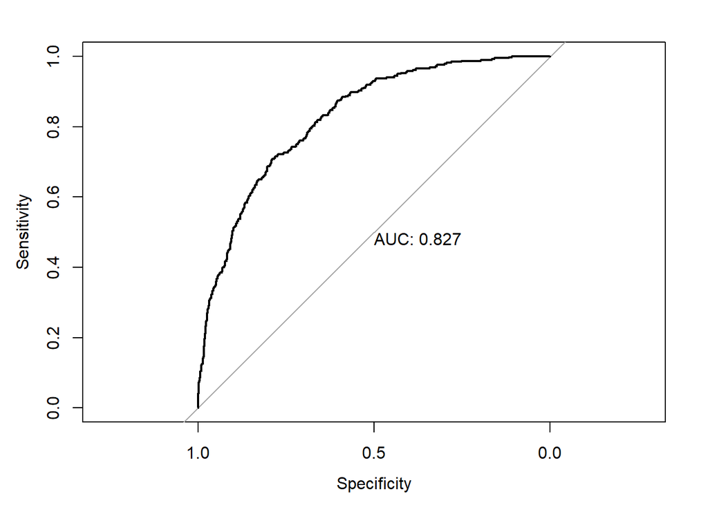

```
Call:
roc.default(response = customer_thresholds$Actual_Left, predictor = customer_thresholds$Probability_Left,     plot = TRUE, print.auc = TRUE)

Data: customer_thresholds$Probability_Left in 1020 controls (customer_thresholds$Actual_Left Current) < 380 cases (customer_thresholds$Actual_Left Left).
Area under the curve: 0.8266
```

```
Call:
qda(Status ~ Gender + Partner + SeniorCitizen + Dependents +
    Tenure + PhoneService + MultipleLines2 + InternetService +
    OnlineSecurity2 + OnlineBackup2 + DeviceProtection2 + TechSupport2 +
    StreamingTV2 + StreamingMovies2 + Contract + PaperlessBilling +
    PaymentMethod + MonthlyCharges + sqrt(TotalCharges), data = customer.train)

Prior probabilities of groups:
  Current      Left
0.7363815 0.2636185

Group means:
        GenderMale PartnerYes SeniorCitizen1 DependentsYes   Tenure PhoneServiceYes
Current  0.5078826  0.5280136      0.1275770     0.3419840 37.55057       0.9061363
Left     0.4939024  0.3556911      0.2520325     0.1727642 17.80352       0.9112466
        MultipleLines2Yes InternetServiceFiber optic InternetServiceNo
Current         0.4152316                  0.3490177         0.2740723
Left            0.4525745                  0.6944444         0.0596206
        OnlineSecurity2Yes OnlineBackup2Yes DeviceProtection2Yes TechSupport2Yes
Current          0.3359204        0.3689061            0.3657531       0.3359204
Left             0.1544715        0.2757453            0.2906504       0.1558266
        StreamingTV2Yes StreamingMovies2Yes ContractOne year ContractTwo year
Current       0.3669658           0.3710890       0.25151589       0.31651710
Left          0.4376694           0.4363144       0.08807588       0.02439024
        PaperlessBillingYes PaymentMethodCredit card (automatic)
Current           0.5343197                            0.2517584
Left              0.7506775                            0.1205962
        PaymentMethodElectronic check PaymentMethodMailed check MonthlyCharges
Current                     0.2469076                 0.2503032       61.47105
Left                        0.5779133                 0.1659892       74.41087
        sqrt(TotalCharges)
Current           44.33831
Left              31.71122
```

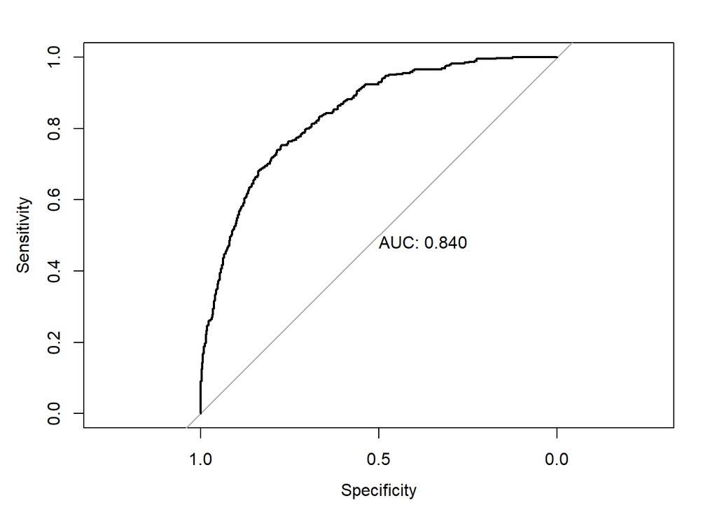

```
Call:
roc.default(response = customer_thresholds$Actual_Left, predictor = customer_thresholds$Probability_Left,     plot = TRUE, print.auc = TRUE)

Data: customer_thresholds$Probability_Left in 1020 controls (customer_thresholds$Actual_Left Current) < 380 cases (customer_thresholds$Actual_Left Left).
Area under the curve: 0.8401
```

### Model Choice

- The Last Model using the Square root of the total Charges has the highest area under the curve, therefore I will be using it for analysis.

```
Confusion Matrix and Statistics

          Reference
Prediction Current Left
   Current     789   95
   Left        231  285

               Accuracy : 0.7671
                 95% CI : (0.7441, 0.7891)
    No Information Rate : 0.7286
    P-Value [Acc > NIR] : 0.0005535

                  Kappa : 0.4707

 Mcnemar's Test P-Value : 7.606e-14

            Sensitivity : 0.7735
            Specificity : 0.7500
         Pos Pred Value : 0.8925
         Neg Pred Value : 0.5523
             Prevalence : 0.7286
         Detection Rate : 0.5636
   Detection Prevalence : 0.6314
      Balanced Accuracy : 0.7618

       'Positive' Class : Current
```

```
Confusion Matrix and Statistics

          Reference
Prediction Current Left
   Current     763   90
   Left        257  290

               Accuracy : 0.7521
                 95% CI : (0.7287, 0.7746)
    No Information Rate : 0.7286
    P-Value [Acc > NIR] : 0.0246

                  Kappa : 0.4493

 Mcnemar's Test P-Value : <2e-16

            Sensitivity : 0.7480
            Specificity : 0.7632
         Pos Pred Value : 0.8945
         Neg Pred Value : 0.5302
             Prevalence : 0.7286
         Detection Rate : 0.5450
   Detection Prevalence : 0.6093
      Balanced Accuracy : 0.7556

       'Positive' Class : Current
```

```
Confusion Matrix and Statistics

          Reference
Prediction Current Left
   Current     809  105
   Left        211  275

               Accuracy : 0.7743
                 95% CI : (0.7515, 0.7959)
    No Information Rate : 0.7286
    P-Value [Acc > NIR] : 5.118e-05

                  Kappa : 0.4752

 Mcnemar's Test P-Value : 3.490e-09

            Sensitivity : 0.7931
            Specificity : 0.7237
         Pos Pred Value : 0.8851
         Neg Pred Value : 0.5658
             Prevalence : 0.7286
         Detection Rate : 0.5779
   Detection Prevalence : 0.6529
      Balanced Accuracy : 0.7584

       'Positive' Class : Current
```

### Overall Takeways

The best model is the squared root of total charges. The ideal threshold is a 60% threshold for the probability of a customer leaving as this has the highest prediction accuracy of .7743

## 6. Decision Trees

- Use the training set to build a Decision Tree model to predict the probability for losing a customer.
- Try different combinations of variables and identify the model with the largest prediction accuracy.

```
Classification tree:
tree(formula = Status ~ Gender + SeniorCitizen + Partner + Dependents +
    Tenure + PhoneService + MultipleLines2 + InternetService +
    OnlineSecurity2 + OnlineBackup2 + DeviceProtection2 + TechSupport2 +
    StreamingTV2 + StreamingMovies2 + Contract + PaperlessBilling +
    PaymentMethod + MonthlyCharges + TotalCharges, data = customer.train)
Variables actually used in tree construction:
[1] "Contract"        "InternetService" "Tenure"
Number of terminal nodes:  6
Residual mean deviance:  0.8792 = 4917 / 5593
Misclassification error rate: 0.2095 = 1173 / 5599
```

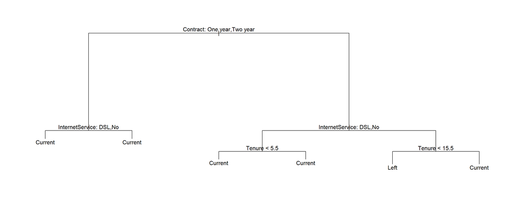

```
node), split, n, deviance, yval, (yprob)
      * denotes terminal node

 1) root 5599 6459.0 Current ( 0.73638 0.26362 )
   2) Contract: One year,Two year 2508 1222.0 Current ( 0.93381 0.06619 )
     4) InternetService: DSL,No 1741  522.1 Current ( 0.96554 0.03446 ) *
     5) InternetService: Fiber optic 767  616.2 Current ( 0.86180 0.13820 ) *
   3) Contract: Month-to-month 3091 4213.0 Current ( 0.57619 0.42381 )
     6) InternetService: DSL,No 1394 1654.0 Current ( 0.71951 0.28049 )
      12) Tenure < 5.5 596  805.8 Current ( 0.59228 0.40772 ) *
      13) Tenure > 5.5 798  765.4 Current ( 0.81454 0.18546 ) *
     7) InternetService: Fiber optic 1697 2341.0 Left ( 0.45846 0.54154 )
      14) Tenure < 15.5 821 1024.0 Left ( 0.31547 0.68453 ) *
      15) Tenure > 15.5 876 1184.0 Current ( 0.59247 0.40753 ) *
```

```r
plot(tree.Customer.train)
# The argument *pretty = 0* instructs R to include the category names for any qualitative predictors, rather than simply displaying a letter for each category
text(tree.Customer.train, pretty = 0)
```